# Informe sobre la contratación pública en la Comunidad de Madrid

## Nota metodológica

El siguiente informe está elaborado a partir de un extracción del [portal de contratación de la Comunidad de Madrid](http://www.madrid.org/cs/Satellite?cid=1224915242285&language=es&pagename=PortalContratacion%2FPage%2FPCON_buscadorAvanzado) de 1.211.902 contratos con número de referencia único para asegurarnos de que no hay duplicados. La extracción se ha realizado utilizando una técnica de [web scrapping](https://es.wikipedia.org/wiki/Web_scraping). Los scripts utilizados y csv resultantes se pueden consultar en [este repositorio](https://github.com/meneos/contratacionCM). Por problemas técnicos los calculos de importe total para las licitaciones y los contratos adjudicados sin publicidad se refieren a las cantidades presupuestadas no a las finalmente adjudicadas.

## Cuadro resumen del número de contratos según procedimiento de adjudicación (2015-2017)

*Los datos de contratos menores de 2015 solo están disponibles para el periodo julio-diciembre.

| Tipo de procedimiento | 2015 | 2016 | 2017 |
| --- | --- | --- | --- |
| Contratos adjudicados por procedimientos sin publicidad | 159 | 538 | 486 |
| Contratos Menores* | 123.577 | 476.785 | 611.522 |
| Convocatoria anunciada a licitación | 580 | 1.020 | 866 |

## Datos de contratación respecto al presupuesto

*Los datos de contratos menores de 2015 solo están disponibles para el periodo julio-diciembre. **Para los porcentajes de 2017 se usa el presupuesto consolidado ya que no está disponible el dato de presupuesto liquidado.

|  | 2015 | 2016 | 2017** |
| --- | --- | --- | --- |
| Presupuesto CM no financiero SEC | 17.418.600.000 € | 17.912.100.000 € | 18.538.400.000 € |
| Presupuesto CM consolidado | 20.819.125.630 € | 20.103.548.245 € | 20.504.093.715 € |
| Liquidacion presupuesto CM consolidado | 20.632.900.480 € | 19.967.639.832 € | NA |
| **Contratos Menores** |  |  |  |
| Importe contratos menores* | 194.644.029 € | 717.693.582 € | 984.529.637 € |
| % contratos menores | 0.94% | 3.6% | 4.8% |
| **Procedimientos sin publicidad** |  |  |  |
| Importe adjudicados sin publicidad | 39.294.001 € | 416.375.213 € | 560.973.798 € |
| % adjudicados sin publicidad | 0.19% | 2.08% | 2.74% |
| **Procedimientos con convoctoria anunciada** |  |  |  |
| Importe adjudicados con convocatoria anunciada | 732.904.368 € | 1.099.398.811 € | 2.024.109.105 € |
| % adjudicados con convocatoria anunciada | 3.55% | 5.5% | 9.87% |

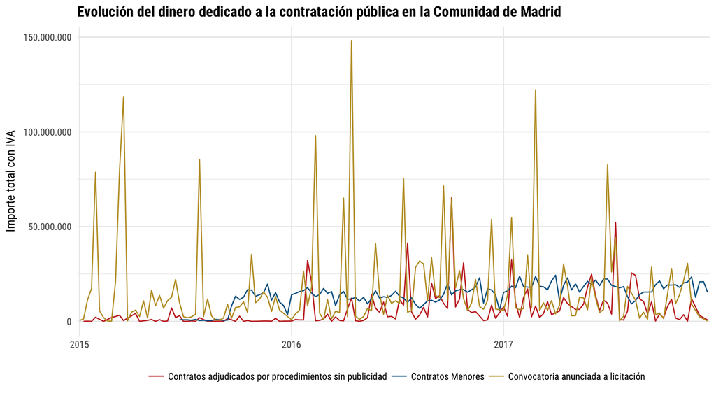

Los contratos en los que se gasta más dinero son los de suministro. Esto tiene que ver sobre todo con el tipo de compras que se hacen desde los hospitales de la red madrileña de salud. Gran cantidad de contratos menores para la compra de medicamentos y suministros sanitarios que convierten a la Consejería de Sanidad en la que más dinero gasta en contratos menores.

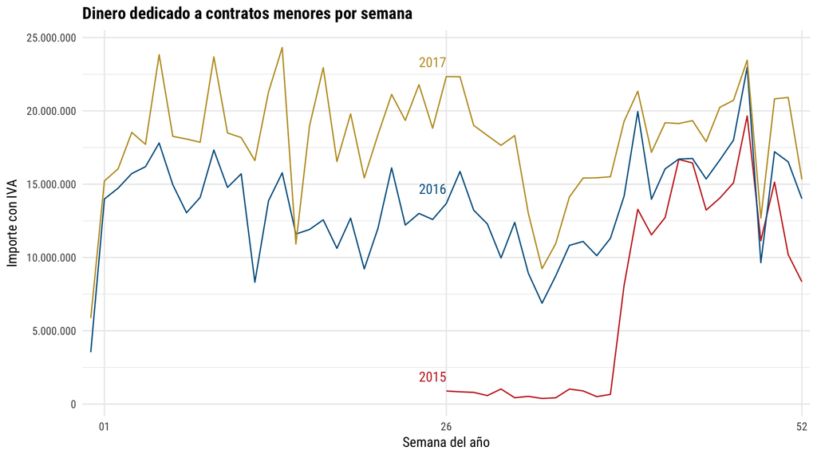

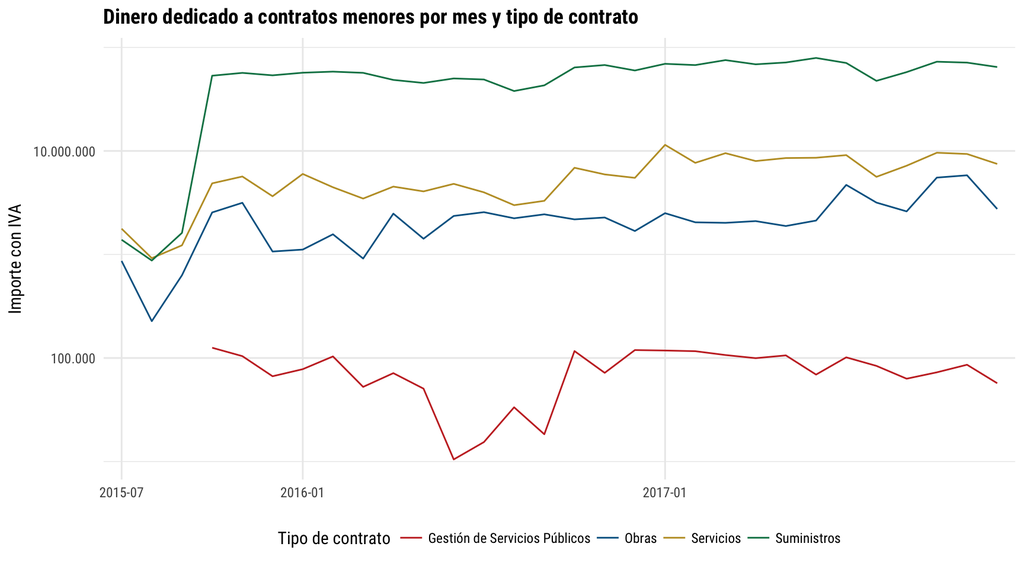

## Principales entidades adjudicadoras

Los datos corresponden al periodo julio de 2015-diciembre de 2017

| Entidad adjudicadora | Número de contratos menores | Importe total con IVA |
| --- | --- | --- |
| Consejería de Sanidad | 1.142.048 | 1.676.627.468 |
| Consejería de Presidencia, Justicia y Portavocía del Gobierno | 18.201 | 57.830.363 |
| Consejería de Educación e Investigación | 3.525 | 28.902.419 |
| Consejería de Políticas Sociales y Familia | 6.877 | 21.209.099 |
| Consejería de Medio Ambiente, Administración Local y Ordenación del Territorio | 4.220 | 20.868.824 |
| Consejería de Transportes, Vivienda e Infraestructuras | 3.812 | 19.509.631 |
| Consejería de Economía, Empleo y Hacienda | 2.179 | 12.590.548 |
| Consejería de Cultura, Turismo y Deportes | 2.529 | 7.842.965 |
| Fundación para la Investigación Biomédica del Hospital Universitario 12 de Octubre | 3.887 | 3.554.083 |
| Fundación para la Investigación Biomédica del Hospital Gregorio Marañón | 3.540 | 2.981.398 |

Este gráfico revela hasta qué punto la Consejería de Sanidad es el principal adjudicador de contratos menores. Las principales empresas beneficiarias de contratos menores son farmacéuticas o empresas suministradores de material sanitario. Gilead S.A, la mayor beneficiaria, es la fabricante y propietaria del Sovaldi, el medicamento empleado en los tratamientos de Hepatitis C. La empresa matriz tiene su sede fiscal en Irlanda y 2015 fue un año de importantes incrementos de sus beneficios según [este artículo de El Español](https://www.elespanol.com/economia/empresas/20170228/197230886_0.html).

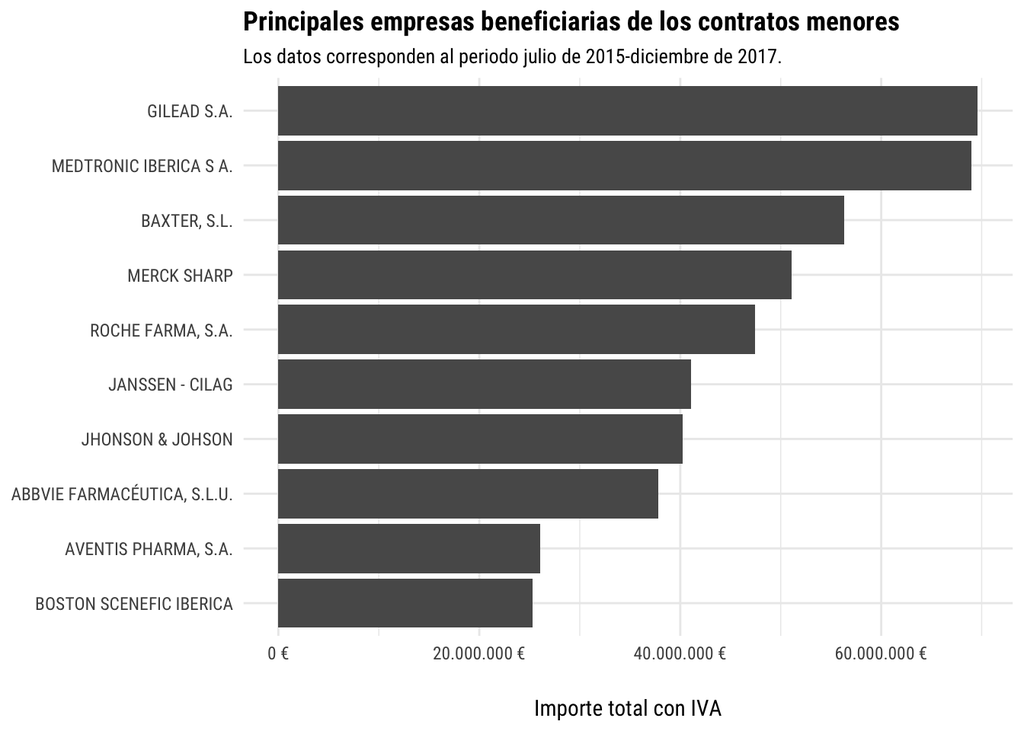